# WebAnalytics

```r
attach(new_data)
```

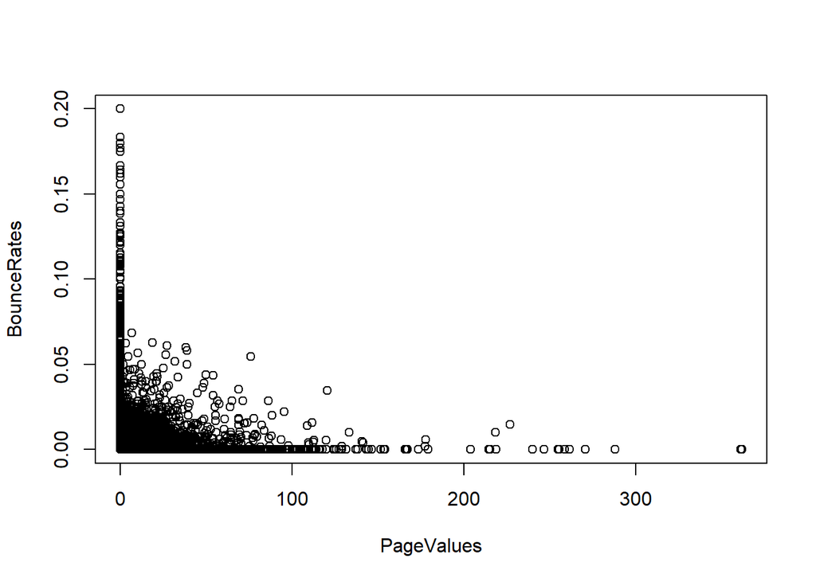

```r
plot(PageValues , BounceRates)
```

A negative relatioship is observed in the above plot which means that an incease in the bounce rates affects the page value negatively. The company should therefore make sure that the bounce rate is kept low by checking the factors that lead to the incease in the rate.

**Month Vs VisitorType**

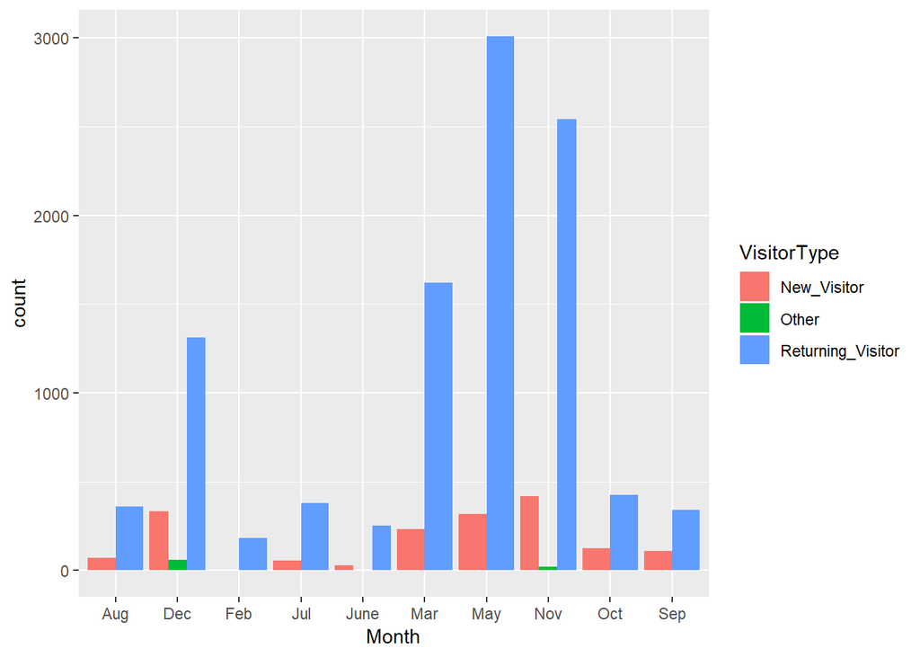

```r
library(ggplot2)

# grouped bar plot
ggplot(new_data,
       aes(x = Month,
           fill = VisitorType)) +
  geom_bar(position = "dodge")
```

We observe that in all the months, returning visitors were more compared to new visitors. November had abit more new visitors compared to the rest of the months. The brand’s Sales and Marketing team should aim to keep the returning visitors to avoid any churning at any point.

**TrafficType Vs VisitorsType**

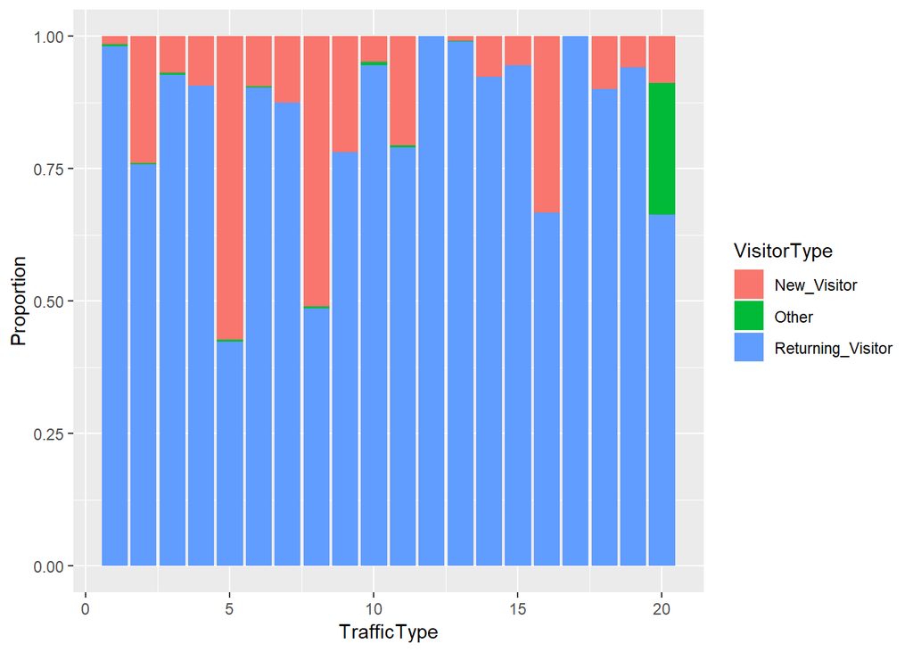

```r
library(ggplot2)

ggplot(new_data,
       aes(x = TrafficType,
           fill = VisitorType)) +
  geom_bar(position = "fill") +
  labs(y = "Proportion")
```

**Revenue Vs Weekend**

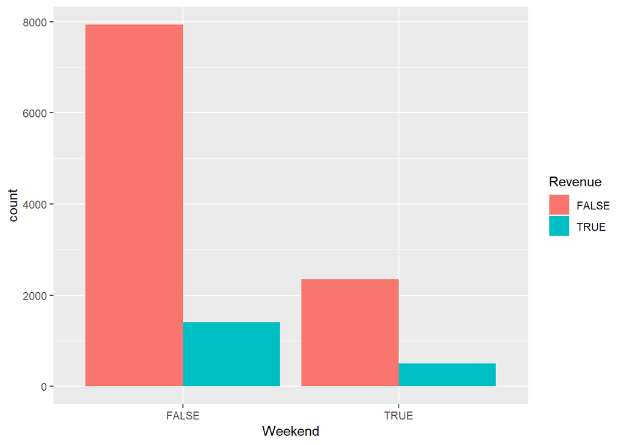

```r
ggplot(new_data,
       aes(x = Weekend,
           fill = Revenue)) +
  geom_bar(position = "dodge")
```

**VisitorType Vs Revenue**

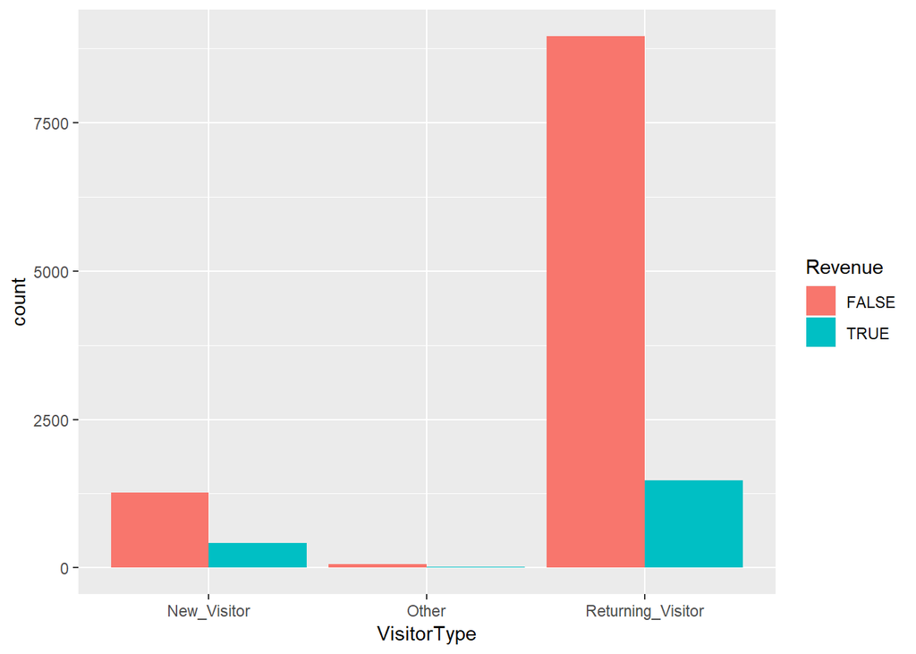

```r
ggplot(new_data,
       aes(x = VisitorType,
           fill = Revenue)) +
  geom_bar(position = "dodge")
```

We observe that the returning visitors but still the revenue acquired was still low. This could mean that the visitors were not exploring on new products hence no purcases. On the new viisitors side, the revenue making views where not optimized which means that the company should have insentives to attract the new customers to making new purchases hence increasing the revenue.

**Region Vs Revenue**

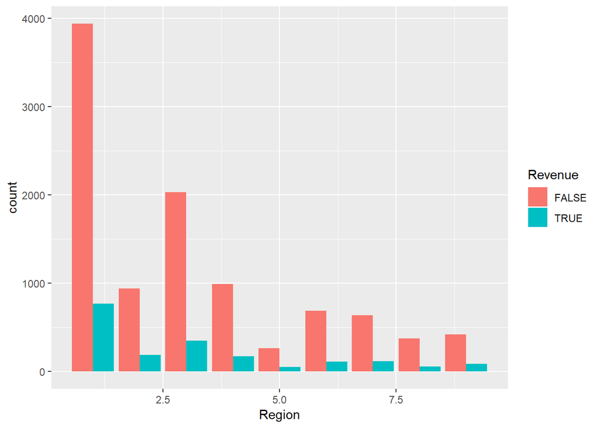

```r
ggplot(new_data,
       aes(x = Region,
           fill = Revenue)) +
  geom_bar(position = "dodge")
```

Across all the regions in the dataset, different site visits where not income generating. This could mean that it’s either there where high bounce and exits rates. This means that the customers did not make to the final goal page.

## Multivariate Analysis

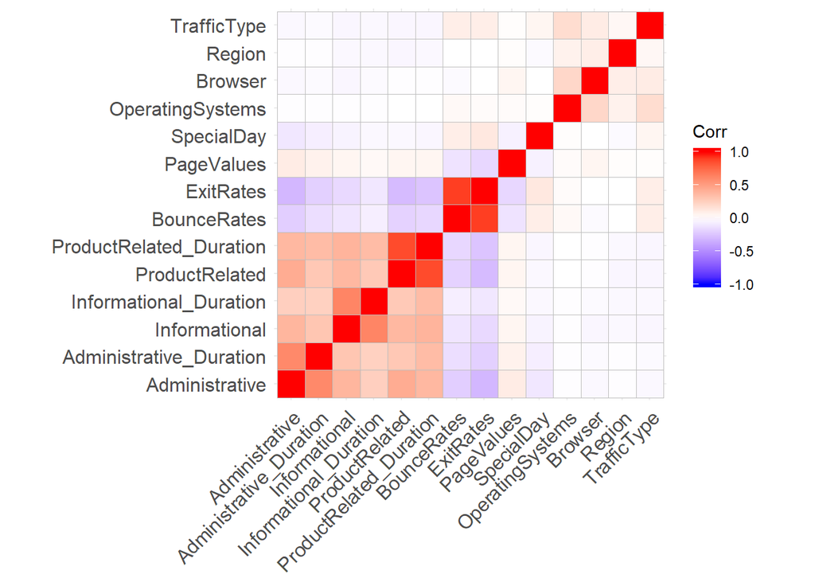

```r
library(ggcorrplot)
library(dplyr)
new_data %>%
    select_if(is.numeric) %>%
    cor %>%
    ggcorrplot()
```

There is a positive correlation betwen the various website pages. We also observe a postitive relationship between productRelated Vs ProductRelated_Duration A positive correlation is observed between the counce rates and exit rates

*Preview the dataset again**

```r
head(new_data)
```

```
##   Administrative Administrative_Duration Informational
## 1              0                       0             0
## 2              0                       0             0
## 3              0                      -1             0
## 4              0                       0             0
## 5              0                       0             0
## 6              0                       0             0
##   Informational_Duration ProductRelated ProductRelated_Duration
## 1                      0              1                0.000000
## 2                      0              2               64.000000
## 3                     -1              1               -1.000000
## 4                      0              2                2.666667
## 5                      0             10              627.500000
## 6                      0             19              154.216667
##   BounceRates ExitRates PageValues SpecialDay Month OperatingSystems
## 1  0.20000000 0.2000000          0          0   Feb                1
## 2  0.00000000 0.1000000          0          0   Feb                2
## 3  0.20000000 0.2000000          0          0   Feb                4
## 4  0.05000000 0.1400000          0          0   Feb                3
## 5  0.02000000 0.0500000          0          0   Feb                3
## 6  0.01578947 0.0245614          0          0   Feb                2
##   Browser Region TrafficType       VisitorType Weekend Revenue
## 1       1      1           1 Returning_Visitor   FALSE   FALSE
## 2       2      1           2 Returning_Visitor   FALSE   FALSE
## 3       1      9           3 Returning_Visitor   FALSE   FALSE
## 4       2      2           4 Returning_Visitor   FALSE   FALSE
## 5       3      1           4 Returning_Visitor    TRUE   FALSE
## 6       2      1           3 Returning_Visitor   FALSE   FALSE
```

Get the class label in another variable

```r
class_lbl <- new_data["Revenue"]
colnames(class_lbl)
```

```
## [1] "Revenue"
```

**Convert the categorical variables to numeric**

```r
new_data$Month <- as.numeric(new_data$Month)
new_data$VisitorType <- as.numeric(new_data$VisitorType)
new_data$Weekend <- as.numeric(new_data$Weekend)
```

**Apply the K-Means Algorithm**

```r
# Applying the K-means clustering algorithm with no. of centroids(k)=3

k_result<- kmeans(new_data,3)

# Previewing the no. of records in each cluster
#
k_result$size
```

```
## [1]   207  1973 10019
```

There are 3 clusters which means that the customers have been classified into groups based on their characteristics.

```r
# Get the value of cluster center datapoint value(3 centers for k=3)

k_result$centers
```

```
##   Administrative Administrative_Duration Informational
## 1       7.439614               295.36489     2.7487923
## 2       4.324886               154.85382     1.1743538
## 3       1.843797                62.85791     0.3314702
##   Informational_Duration ProductRelated ProductRelated_Duration
## 1              266.72309      236.10628              10886.1744
## 2               84.73057       77.77293               3356.5135
## 3               20.22114       18.84030                584.3451
##   BounceRates  ExitRates PageValues SpecialDay    Month OperatingSystems
## 1 0.005939756 0.01968831   4.521370 0.03091787 6.782609         2.149758
## 2 0.007126288 0.02167382   8.020426 0.05078561 6.498733         2.136341
## 3 0.023369600 0.04585102   5.574840 0.06481685 6.090129         2.121469
##    Browser   Region TrafficType VisitorType   Weekend   Revenue
## 1 2.309179 2.584541    3.618357    2.985507 0.2512077 0.3381643
## 2 2.311201 3.092752    3.706031    2.902686 0.2184491 0.2508870
## 3 2.368400 3.176964    4.156602    2.673421 0.2368500 0.1340453
```

We see how the the different customers have been clustered to the 3 different clusters.

**Plot the distribution of the the clusters**

```r
par(mfrow= c(2,2), mar= c(5,4,2,2))
```

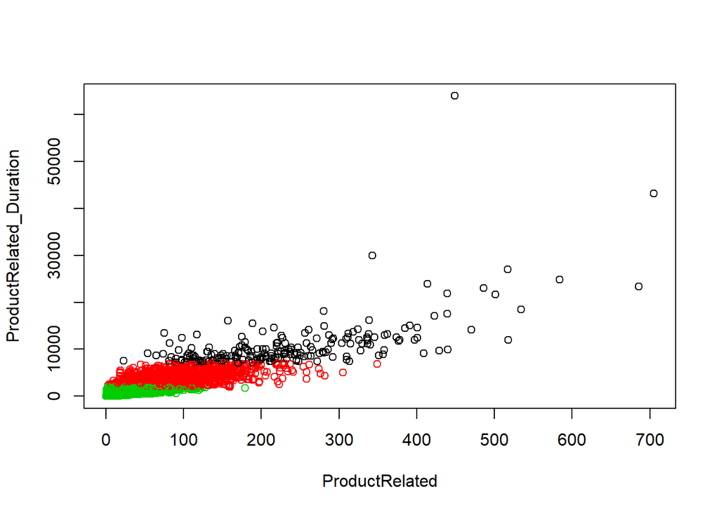

```r
#Plot the ProductRelated Vs ProductRelated_Duration Page to see the distribution
plot(new_data[c(5,6)], col = k_result$cluster)
```

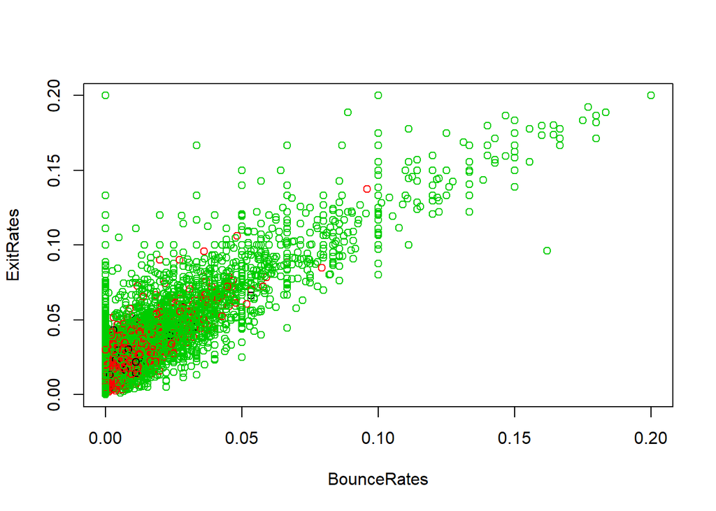

```r
#Plot the BounceRate Vs Exitrate
plot(new_data[c(7,8)], col = k_result$cluster)
```

## Hierarchical clustering

```r
# We start by computing some descriptive statistics
desc_stats <- data.frame(
  Min = apply(new_data, 2, min),    # minimum
  Med = apply(new_data, 2, median), # median
  Mean = apply(new_data, 2, mean),  # mean
  SD = apply(new_data, 2, sd),      # Standard deviation
  Max = apply(new_data, 2, max)     # Maximum
)
desc_stats <- round(desc_stats, 1)
head(desc_stats)
```

```
##                         Min   Med   Mean     SD     Max
## Administrative            0   1.0    2.3    3.3    27.0
## Administrative_Duration  -1   9.0   81.7  177.5  3398.8
## Informational             0   0.0    0.5    1.3    24.0
## Informational_Duration   -1   0.0   34.8  141.5  2549.4
## ProductRelated            0  18.0   32.1   44.6   705.0
## ProductRelated_Duration  -1 609.5 1207.5 1919.9 63973.5
```

```r
# Scale the data to make it comparable
#
new_data<- scale(new_data)
head(new_data)
```

```
##      Administrative Administrative_Duration Informational
## [1,]     -0.7025315              -0.4601081    -0.3988128
## [2,]     -0.7025315              -0.4601081    -0.3988128
## [3,]     -0.7025315              -0.4657410    -0.3988128
## [4,]     -0.7025315              -0.4601081    -0.3988128
## [5,]     -0.7025315              -0.4601081    -0.3988128
## [6,]     -0.7025315              -0.4601081    -0.3988128
##      Informational_Duration ProductRelated ProductRelated_Duration
## [1,]             -0.2462725     -0.6963635              -0.6289343
## [2,]             -0.2462725     -0.6739424              -0.5955997
## [3,]             -0.2533417     -0.6963635              -0.6294551
## [4,]             -0.2462725     -0.6739424              -0.6275453
## [5,]             -0.2462725     -0.4945739              -0.3020990
## [6,]             -0.2462725     -0.2927843              -0.5486101
##       BounceRates  ExitRates PageValues SpecialDay     Month
```

[output cut: 20 more lines]

```r
#Find the Euclidean distance between observations using the dist() function
d <- dist(new_data, method = "euclidean")
```

```r
# We then perform hierarchical clustering using the Ward's method

res.hc <- hclust(d, method = "ward.D2" )
```

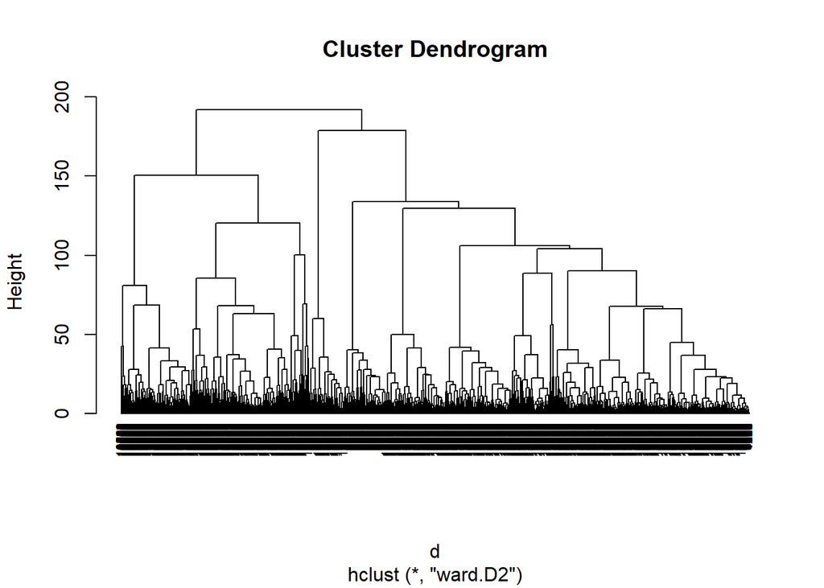

```r
# We plot the obtained dendrogram

plot(res.hc, cex = 0.6, hang = -1)
```

# Conclusion

An overview of the company’s performance is that the company is growing well on the marketting side which is a good thing in the market place. This is as per the low exit and bounce rates(20%) projected by the different pages compared to the Google Analytics figure of above 70% which transaltes to poor performance of the company. The company’s money in is quite low and they should change on the different tactics of handling the website to make sure revenue flows improve.

# Recommendation

The brand’s Sales and Marketing team should make sure that both ExitRates and BounceRates are low enough. This would transalte to customers helping the company meet it’s main goal which is maximising the revenue. With increased pagevalues,that would mean that the company is likely to meet it main focus of making revenue from the online shop in place. The concerned teams should make easy access for customers to the website by reducing the unnecessary ad plays to different pages and also make sure that the loading speed is good to enable a customer move from one page to the other with ease. Based on the 3 clusters from the data, the company should study further each cluster for better understanding and also get to know what incentives to give just incase the company is more money oriented.